# R Laboratory 1

**Exercise 1 - Lakes of Scotland**

• The table that can be found at https://en.wikipedia.org/wiki/List_of_lochs_of_Scotland gives the volume, area, length and maximum and mean depths of some Scottish lakes. Create vectors, holding the lake’s name and all the parameters and build a dataframe called scottish.lakes from the vectors

1 evaluate the highest and lowest volume and area lake

2 order the frame with respect to the area and determine the two largest area lakes

3 by summing up the areas occpupied by the lakes, determine the area of Scotland covered by water

```r
scottish.lakes <- read.table('Data/LochLakes.csv', header=T , sep=',')

head(scottish.lakes)
```

|  | Loch | Volume.km.. | Volume.mi.. | Area.km2. | Area.mi2. | Length.km. | Length.mi. | Max..depth.m. | Max..depth.ft. | Mean.depth.m. | Mean.depth.ft..6. |
| --- | --- | --- | --- | --- | --- | --- | --- | --- | --- | --- | --- |
| 1 | Loch Ness | 7.45 | 1.79 | 56.0 | 22.0 | 36.2 | 22.5 | 227 | 745 | 132.0 | 433[4] |
| 2 | Loch Lomond | 2.60 | 0.62 | 71.0 | 27.0 | 36.0 | 22.0 | 190 | 620 | 37.0 | 121[7] |
| 3 | Loch Morar | 2.30 | 0.55 | 26.7 | 10.3 | 18.8 | 11.7 | 310 | 1,020 | 87.0 | 285[8] |
| 4 | Loch Tay | 1.60 | 0.38 | 26.4 | 10.2 | 23.0 | 14.0 | 150 | 490 | 60.6 | 199[9] |
| 5 | Loch Awe | 1.20 | 0.29 | 39.0 | 15.0 | 41.0 | 25.0 | 94 | 308 | 32.0 | 105[10] |
| 6 | Loch Maree | 1.09 | 0.26 | 28.6 | 11.0 | 20.0 | 12.0 | 114 | 374 | 38.0 | 125[5] |

```r
#1 - evaluate the highest and lowest volume and area lake

indmax1 <- which.max(scottish.lakes[,'Volume.km..'])
indmax2 <- which.max(scottish.lakes[,'Area.km2.'])

indmin1 <- which.min(scottish.lakes[,'Volume.km..'])
indmin2 <- which.min(scottish.lakes[,'Area.km2.'])

cat("The lake with the highest Volume is ", paste(scottish.lakes[indmax1,1]), " with ", max(scottish.lakes[,'Volume.km..'])," km3")
```

```
The lake with the highest Volume is  Loch Ness  with  7.45  km3
```

```r
cat("The lake with the highest Area is ", paste(scottish.lakes[indmax2,1]), " with ", max(scottish.lakes[,'Area.km2.'])," km2")
```

```
The lake with the highest Area is  Loch Lomond  with  71  km2
```

```r
cat("The lake with the Lowest Volume is ", paste(scottish.lakes[indmin1,1]), " with ", min(scottish.lakes[,'Volume.km..'])," km3")
```

```
The lake with the Lowest Volume is  Loch Shin  with  0.35  km3
```

```r
cat("The lake with the Lowest Area is ", paste(scottish.lakes[indmin2,1]), " with ", min(scottish.lakes[,'Area.km2.'])," km2")
```

```
The lake with the Lowest Area is  Loch Katrine  with  12.4  km2
```

```r
#------------------------------------------------------------------------------------------

#2 - order the frame with respect to the area and determine the two largest area lakes

scottish_order <- scottish.lakes[order(scottish.lakes[,'Area.km2.'] , decreasing = TRUE) , ]
head(scottish_order)
```

|  | Loch | Volume.km.. | Volume.mi.. | Area.km2. | Area.mi2. | Length.km. | Length.mi. | Max..depth.m. | Max..depth.ft. | Mean.depth.m. | Mean.depth.ft..6. |
| --- | --- | --- | --- | --- | --- | --- | --- | --- | --- | --- | --- |
| 2 | Loch Lomond | 2.60 | 0.62 | 71.0 | 27.0 | 36.0 | 22.0 | 190 | 620 | 37.0 | 121[7] |
| 1 | Loch Ness | 7.45 | 1.79 | 56.0 | 22.0 | 36.2 | 22.5 | 227 | 745 | 132.0 | 433[4] |
| 5 | Loch Awe | 1.20 | 0.29 | 39.0 | 15.0 | 41.0 | 25.0 | 94 | 308 | 32.0 | 105[10] |
| 6 | Loch Maree | 1.09 | 0.26 | 28.6 | 11.0 | 20.0 | 12.0 | 114 | 374 | 38.0 | 125[5] |
| 3 | Loch Morar | 2.30 | 0.55 | 26.7 | 10.3 | 18.8 | 11.7 | 310 | 1,020 | 87.0 | 285[8] |
| 4 | Loch Tay | 1.60 | 0.38 | 26.4 | 10.2 | 23.0 | 14.0 | 150 | 490 | 60.6 | 199[9] |

```r
cat("The two lakes with the largest Area are ", scottish_order[1,'Loch'], " and " , scottish_order[2,'Loch'], " respectively with an Area of ", scottish_order[1,'Area.km2.'] , " and " , scottish_order[2,'Area.km2.'], " km2")
```

```
The two lakes with the largest Area are  Loch Lomond  and  Loch Ness  respectively with an Area of  71  and  56  km2
```

```r
#------------------------------------------------------------------------------------------

#3 - by summing up the areas occupied by the lakes, determine the area of Scotland covered by water

total_area <- sum(scottish.lakes[,'Area.km2.'])
cat('The total area of Scotland occupied by water is equal to ', total_area , 'km2')
```

```
The total area of Scotland occupied by water is equal to  371.7 km2
```

**Exercise 2 - Crude Oil Production**

• The following CSV file https://drive.google.com/file/d/13WkinYhJNSr_XCldb3wpZOI0fgjer7Iw/view contains data on crude oil prices from 1861 to 2020, measured in US dollars per barrel.

1 Write R code that is able to read the file and import it in a data frame structure. (Hint: before loading the file, open it with a text editor and check its structure).

2 produce a plot with the Oil price as a function of the year

3 which is the highest price in history ? When did it occur ?

3 plot the derivative of the curve, simply evaluated with the finite difference formula (forward derivative): dprice / dyear = pricej+1 − pricej

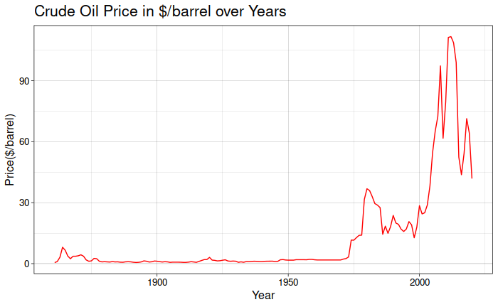

```r
#1 - read data
oil <- read.csv('Data/crude-oil-prices.csv')
colnames(oil) <- c("Entity", "Code", "Year", "Price")   #more accessible

#2 - produce a plot with the Oil price as a function of the year
library(ggplot2)

plot <- ggplot(oil, aes(x=Year , y=Price)) + theme_linedraw()
plot <- plot + ggtitle('Crude Oil Price in $/barrel over Years')
plot <- plot + labs(x="Year", y="Price($/barrel)")
plot <- plot + theme(plot.title = element_text(size=16),
                  axis.text.x = element_text(size=10),
                  axis.text.y = element_text(size=10),
                  axis.title.x = element_text(size=12),
                  axis.title.y = element_text(size=12))
plot + geom_line(color="red")
```

```r
#--------------------------
#3 - which is the highest price in history? when did it occur?

ind_pricemax <- which.max(oil[,'Price'])

cat("The year with the highest price of crude oil is ", paste(oil[ind_pricemax,'Year']), " with ", max(oil[,'Price']),"$/barrel")
```

```
The year with the highest price of crude oil is  2012  with  111.6697 $/barrel
```

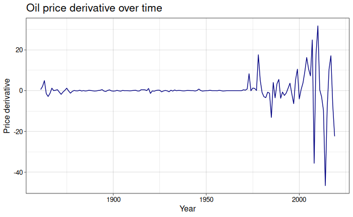

```r
#--------------------------
#4 - plot the derivative of the curve

price_deriv <- c(diff(oil[,'Price']), NA)

plot2 <- ggplot(oil[1:nrow(oil)-1,], aes(x=Year , y=price_deriv[-length(price_deriv)]))
plot2 <- plot2 + theme_linedraw() + ggtitle('Oil price derivative over time')
plot2 <- plot2 + labs(x="Year", y="Price derivative")
plot2 <- plot2 + theme(plot.title = element_text(size=16),
                  axis.text.x = element_text(size=10),
                  axis.text.y = element_text(size=10),
                  axis.title.x = element_text(size=12),
                  axis.title.y = element_text(size=12))
plot2 + geom_line(color="navy")
```

**Exercise 3 - World Coal Production**

• The following CSV file https://drive.google.com/file/d/1U1hK5o_d3vl8twwGaRJNcDJ79O9I5zJ1/view?usp=sharing

contains data on the coal production (in TW · hour) for several countries in the World.

1 Write R code that is able to read the file and import it in a tibble structure

2 count the number of countries available in the file and produce a barplot with the number of entries for each country

For the following items select only the years ≥ 1970: 3 selecting only the year after 1970, determine the total integrated production for each country and print the top 5 Countries with highest coal productions

4 for the 5 top Countries, create a plot of production as a function of time

5 generate a plot with the cumulative sum of the World’s coal production over the years

```r
#1 - read coal-production-by-country.csv and import in a tibble structure
library(tibble)

coal = tibble(read.csv("Data/coal-production-by-country.csv"))
colnames(coal) <- c("Entity", "Code", "Year", "CoalProdTWh")   #more accessible
head(coal)
```

| Entity | Code | Year | CoalProdTWh |
| --- | --- | --- | --- |
| Afghanistan | AFG | 1900 | 0 |
| Afghanistan | AFG | 1901 | 0 |
| Afghanistan | AFG | 1902 | 0 |
| Afghanistan | AFG | 1903 | 0 |
| Afghanistan | AFG | 1904 | 0 |
| Afghanistan | AFG | 1905 | 0 |

```r
#----------------------
#2 - count the number of countries available in the file and produce a barplot

countries <- unique(coal[,'Entity'])
cat("Counting , the number of avalaible countries in the file are " , nrow(countries))
```

```
Counting , the number of avalaible countries in the file are  200
```

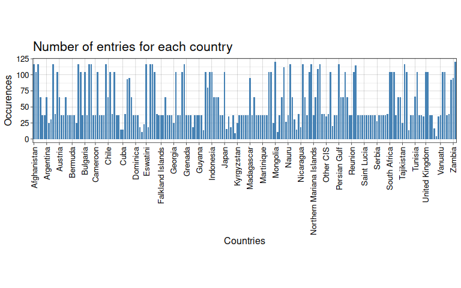

```r
library(ggplot2)

plot <- ggplot(coal, aes(x=Entity)) + theme_linedraw()
plot <- plot + ggtitle('Number of entries for each country')
plot <- plot + labs(x="Countries", y="Occurences")
plot <- plot + theme(plot.title = element_text(size=16),
                  axis.text.x = element_text(size=10, angle = 90, hjust = 1, vjust = 0.5),
                  axis.text.y = element_text(size=10),
                  axis.title.x = element_text(size=12),
                  axis.title.y = element_text(size=12),
                  aspect.ratio = 0.2)
plot <- plot + scale_x_discrete(breaks =unique(coal$Entity)[c(TRUE, rep(FALSE, 5))])
plot + geom_bar(width = 0.75, fill="steelblue")
```

```r
#----------------------
#3 - only the years ≥ 1970: determine the total integrated production for each
#    country and print the top 5 Countries with highest coal productions

coal_ <- coal[coal[,'Year'] >= 1970,]

sum_by_country = aggregate(coal_[,'CoalProdTWh'], coal_[,'Entity'], sum)

sum_df <- data.frame(sum_by_country[1], sum_by_country[2])
colnames(sum_df) <- c("Country", "Tot_Prod")

sum_df = sum_df[order(sum_df$Tot_Prod, decreasing=TRUE), ]
row.names(sum_df) <- NULL

print(sum_df[1:5,])
```

|  | Country | Tot_Prod |
| --- | --- | --- |
| 1 | World | 1260113.2 |
| 2 | Asia Pacific | 690240.5 |
| 3 | Asia and Oceania | 685960.0 |
| 4 | China | 459564.6 |
| 5 | OECD | 438441.4 |

```r
not_countries <- c("World", "Asia Pacific", "Asia and Oceania", "OECD", "North America", "Eurasia", "Europe", "EU-28", "CIS", "South & Central AMerica", "USSR")

top_5 = sum_df[!sum_df$Country %in% not_countries, ]$Country[1:5]
sum_df = sum_df[!sum_df$Country %in% not_countries, ][1:5, ]
row.names(sum_df) <- NULL
cat("The top 5 countries for TWh Coal production")
```

```
The top 5 countries for TWh Coal production
```

```r
print(sum_df)
```

| Country | Tot_Prod |
| --- | --- |
| China | 459564.65 |
| United States | 226068.84 |
| Russia | 101908.49 |
| Australia | 83077.07 |
| India | 77043.45 |

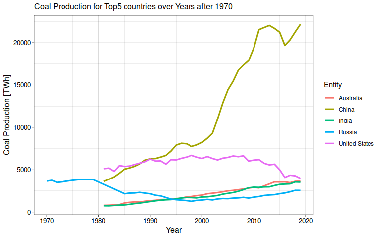

```r
#---------------------------
#4 - for the 5 top Countries, create a plot of production as a function of time

coal_top_5 = coal_[coal_$Entity %in% top_5, ]


plot <- ggplot(coal_top_5, aes(x=Year , y=CoalProdTWh)) + theme_linedraw()
plot <- plot + ggtitle('Coal Production for Top5 countries over Years after 1970')
plot <- plot + labs(x="Year", y="Coal Production [TWh]")
plot <- plot +  geom_line(aes(color=Entity), lwd=1.1)
plot <- plot + theme(plot.title = element_text(size=12),
                  axis.text.x = element_text(size=10),
                  axis.text.y = element_text(size=10),
                  axis.title.x = element_text(size=12),
                  axis.title.y = element_text(size=12))
plot
```

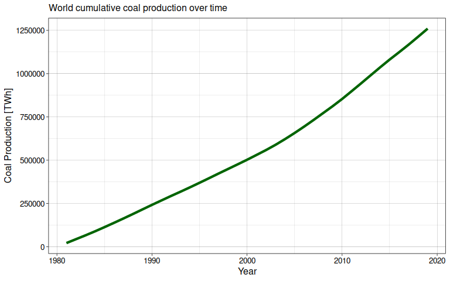

```r
#---------------------------
#5 - generate a plot with the cumulative sum of the World’s coal
#     production over the years

library(dplyr)
world_prod <- filter(coal_, coal_$Entity == 'World')
world_cumsum <- unlist(cumsum(world_prod[,"CoalProdTWh"]))
world_prod['CumulatSum'] <- world_cumsum



plot <- ggplot(world_prod, aes(x = Year, y=world_cumsum)) + theme_linedraw()
plot <- plot + ggtitle('World cumulative coal production over time')
plot <- plot + labs(x="Year", y="Coal Production [TWh]")
plot <- plot + geom_line(lwd=1.5, color="darkgreen")
plot <- plot + theme(plot.title = element_text(size=12),
                  axis.text.x = element_text(size=10),
                  axis.text.y = element_text(size=10),
                  axis.title.x = element_text(size=12),
                  axis.title.y = element_text(size=12))
plot
```

**Exercise 4 - Covid19 Vaccine Data**

• Data on Covid-19 vaccine can be found on. • The file vaccinationsby-manufacturer.csv, (https://github.com/owid/covid-19-data) contains a summary on the vaccination data grouped by Vaccine type and Country.

1 filter() the original tibble by selecting the following countries: Italy

2 plot the number of vaccines given as a function of time for the different vaccine manufacturer

3 from the same tibble plot the total number of vaccines shot per day in Italy

4 do the same exercise for the following countries: Germany and United States of America

```r
library(tibble)
library(dplyr)

cov_data <- tibble(read.csv('Data/covid.csv'))
cov_data$date <- as.Date(cov_data$date)  # convert date column as date type

#1 - filter() the original tibble by selecting the following countries: Italy
cov_ita <- filter(cov_data, cov_data$location == 'Italy')
print(head(cov_ita))
```

| location | date | vaccine | total_vaccinations |
| --- | --- | --- | --- |
| Italy | 2020-12-27 | Moderna | 2 |
| Italy | 2020-12-27 | Pfizer/BioNTech | 7347 |
| Italy | 2020-12-28 | Moderna | 6 |
| Italy | 2020-12-28 | Pfizer/BioNTech | 8848 |
| Italy | 2020-12-29 | Moderna | 11 |
| Italy | 2020-12-29 | Pfizer/BioNTech | 9942 |

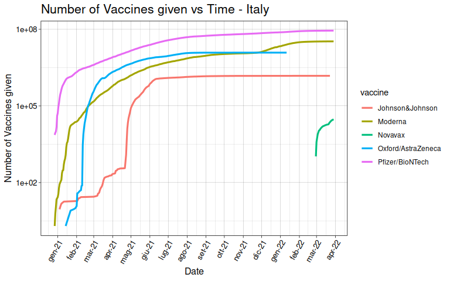

```r
#------------------
#2 - plot the number of vaccines given as a function of time for the different vaccine manufacturer

library(ggplot2)

plot <- ggplot(cov_ita, aes(x=date , y=total_vaccinations , color = vaccine))
plot <- plot + theme_linedraw() + ggtitle('Number of Vaccines given vs Time - Italy')
plot <- plot + labs(x="Date", y="Number of Vaccines given")
plot <- plot + theme(plot.title = element_text(size=16),
            axis.text.x = element_text(size=10, angle = 60, hjust = 1),
            axis.text.y = element_text(size=10),
            axis.title.x = element_text(size=12),
            axis.title.y = element_text(size=12)) + scale_x_date(date_breaks = "1 months",date_labels="%b-%y")                                                               + scale_y_continuous(trans='log10') +
                                                                                geom_line(lwd = 1.1)
plot
```

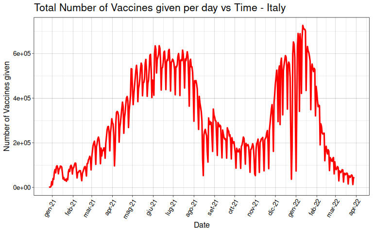

```r
#------------------
#3 - from the same tibble plot the total number of vaccines shot per day in Italy

vaccines_per_day <- rep(0, length(unique(cov_ita$date)))
for (i in 1:length(unique(cov_ita$date))){
    date_ = unique(cov_ita$date)[[i]]
    for (vaccine_ in unique(cov_ita$vaccine)){
        current_shots  = filter(cov_ita, date==date_ & vaccine==vaccine_)
        previous_shots = filter(cov_ita, date==(date_-1) & vaccine==vaccine_)
        if (dim(current_shots)[1]!=0){
            if (dim(previous_shots)[1]!=0){
                vaccines_per_day[i] <- vaccines_per_day[i] + current_shots$total_vaccinations - previous_shots$total_vaccinations
            }
        }
    }
}


plot2 <- ggplot()
plot2 <- plot2 + theme_linedraw() + ggtitle('Total Number of Vaccines given per day vs Time - Italy')
plot2 <- plot2 + labs(x="Date", y="Number of Vaccines given")
plot2 <- plot2 + theme(plot.title = element_text(size=16),
              axis.text.x = element_text(size=10, angle = 60, hjust = 1),
              axis.text.y = element_text(size=10),
              axis.title.x = element_text(size=12),
              axis.title.y = element_text(size=12)) + scale_x_date(date_breaks = "1 months",date_labels="%b-%y")+                   geom_line(aes(x=unique(cov_ita$date) , y=vaccines_per_day), lwd = 1.1 , color='red')
plot2
```

```r
NA
NA
NA
NA
NA
```

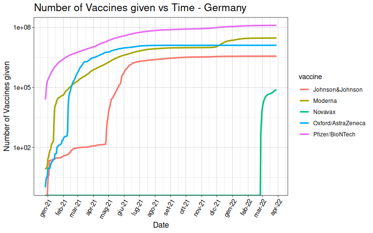

```r
#------------------
#4 - do the same exercise for Germany

library(tibble)
library(dplyr)
library(ggplot2)

cov_ger <- filter(cov_data, cov_data$location == 'Germany')

plot <- ggplot(cov_ger, aes(x=date , y=total_vaccinations , color = vaccine))
plot <- plot + theme_linedraw() + ggtitle('Number of Vaccines given vs Time - Germany')
plot <- plot + labs(x="Date", y="Number of Vaccines given")
plot <- plot + theme(plot.title = element_text(size=16),
                  axis.text.x = element_text(size=10, angle = 60, hjust = 1),
                  axis.text.y = element_text(size=10),
                  axis.title.x = element_text(size=12),
                  axis.title.y = element_text(size=12)) + scale_x_date(date_breaks = "1 months",date_labels="%b-%y") + scale_y_continuous(trans='log10') + geom_line(lwd = 1.1)
plot
```

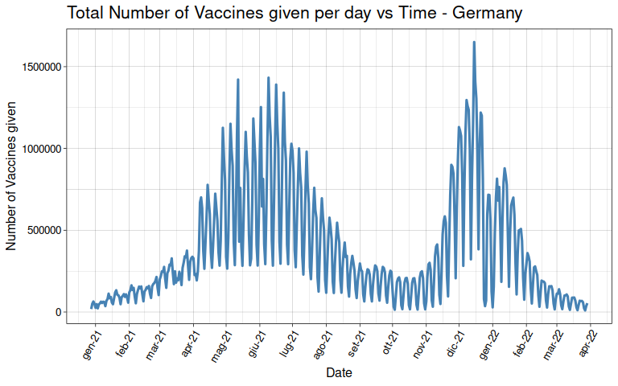

```r
#no problems in data
total_vaccines_per_day <- aggregate(cov_ger$total_vaccinations, list(cov_ger$date),sum)[[2]]
vaccines_per_day <- diff(total_vaccines_per_day)

plot2 <- ggplot()
plot2 <- plot2 + theme_linedraw() + ggtitle('Total Number of Vaccines given per day vs Time - Germany')
plot2 <- plot2 + labs(x="Date", y="Number of Vaccines given")
plot2 <- plot2 + theme(plot.title = element_text(size=16),
              axis.text.x = element_text(size=10, angle = 60, hjust = 1),
              axis.text.y = element_text(size=10),
              axis.title.x = element_text(size=12),
              axis.title.y = element_text(size=12)) + scale_x_date(date_breaks = "1 months",date_labels="%b-%y")+                   geom_line( aes(x=unique(cov_ger$date)[-1] , y=vaccines_per_day), lwd = 1.1 , color='steelblue')
plot2
```

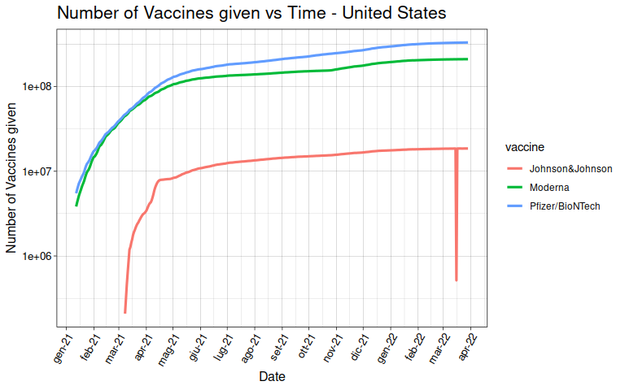

```r
#------------------
#4 - do the same exercise for the United States of America

library(tibble)
library(dplyr)
library(ggplot2)

cov_usa <- filter(cov_data, cov_data$location == 'United States')

plot <- ggplot(cov_usa, aes(x=date , y=total_vaccinations , color = vaccine))
plot <- plot + theme_linedraw() + ggtitle('Number of Vaccines given vs Time - United States')
plot <- plot + labs(x="Date", y="Number of Vaccines given")
plot <- plot + theme(plot.title = element_text(size=16),
              axis.text.x = element_text(size=10, angle = 60, hjust = 1),
              axis.text.y = element_text(size=10),
              axis.title.x = element_text(size=12),
              axis.title.y = element_text(size=12)) + scale_x_date(date_breaks = "1 months",date_labels="%b-%y")                      + scale_y_continuous(trans='log10') + geom_line(lwd = 1.1)

plot
```

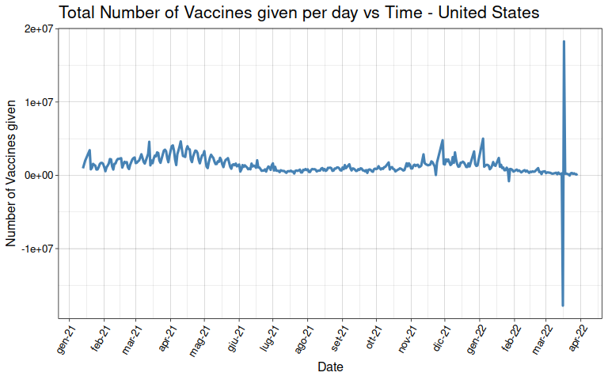

```r
#no problems in data??
total_vaccines_per_day <- aggregate(cov_usa$total_vaccinations, list(cov_usa$date),sum)[[2]]
vaccines_per_day <- diff(total_vaccines_per_day)

plot2 <- ggplot()
plot2 <- plot2 + theme_linedraw() + ggtitle('Total Number of Vaccines given per day vs Time - United States')
plot2 <- plot2 + labs(x="Date", y="Number of Vaccines given")
plot2 <- plot2 + theme(plot.title = element_text(size=16),
            axis.text.x = element_text(size=10, angle = 60, hjust = 1),
            axis.text.y = element_text(size=10),
            axis.title.x = element_text(size=12),
            axis.title.y = element_text(size=12)) + scale_x_date(date_breaks = "1 months",date_labels="%b-%y")+                   geom_line( aes(x=unique(cov_usa$date)[-1] , y=vaccines_per_day), lwd = 1.1 , color='steelblue')
plot2
```

```r
NA
NA
```

Observing these plots there is a problem in the data: around March 2022 the registered number of vaccines given of Johnson&Johnson leads to a negative difference in the Total number of vaccines given… Try to adjust this…

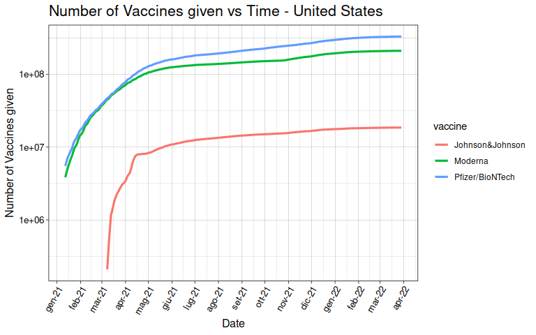

```r
library(tibble)
library(dplyr)
library(ggplot2)

df <- cov_usa[cov_usa$date > as.Date("2022-03-01"), ]
for (i in 1:length(df$date)){
    if(df[[i, "total_vaccinations"]] < mean(df[df$vaccine == "Johnson&Johnson", ]$total_vaccinations)){
        date_ = df[[i, "date"]]
        }
}

# fix the error replacing the bad record with it previous value

bad_record <- which(cov_usa$date == date_ & cov_usa$vaccine == "Johnson&Johnson")
cov_usa[bad_record, ] <- cov_usa[cov_usa$date == date_-1 & cov_usa$vaccine == "Johnson&Johnson", ]


# filter to repair eventual differences
difference_filter <- function(difference){
    for (i in 1:length(difference)){
        if (difference[i]<0){
            difference[i]=0
        }
        if (difference[i]>10*mean(difference)){
            difference[i]=0
        }
    }
    return(difference)
}


plot <- ggplot(cov_usa, aes(x=date , y=total_vaccinations , color = vaccine))
plot <- plot + theme_linedraw() + ggtitle('Number of Vaccines given vs Time - United States')
plot <- plot + labs(x="Date", y="Number of Vaccines given")
plot <- plot + theme(plot.title = element_text(size=16),
                  axis.text.x = element_text(size=10, angle = 60, hjust = 1),
                  axis.text.y = element_text(size=10),
                  axis.title.x = element_text(size=12),
                  axis.title.y = element_text(size=12)) + scale_x_date(date_breaks = "1 months",date_labels="%b-%y")                      + scale_y_continuous(trans='log10') + geom_line(lwd = 1.1)

plot
```

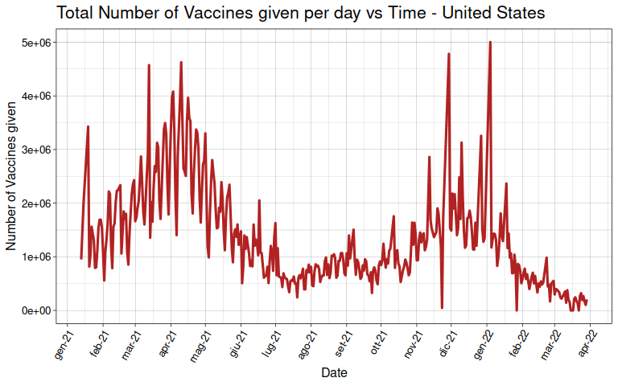

```r
total_vaccines_per_day <- aggregate(cov_usa$total_vaccinations, list(cov_usa$date),sum)[[2]]
vaccines_per_day <- difference_filter(diff(total_vaccines_per_day))

plot2 <- ggplot()
plot2 <- plot2 + theme_linedraw() + ggtitle('Total Number of Vaccines given per day vs Time - United States')
plot2 <- plot2 + labs(x="Date", y="Number of Vaccines given")
plot2 <- plot2 + theme(plot.title = element_text(size=16),
              axis.text.x = element_text(size=10, angle = 60, hjust = 1),
              axis.text.y = element_text(size=10),
              axis.title.x = element_text(size=12),
              axis.title.y = element_text(size=12)) + scale_x_date(date_breaks = "1 months",date_labels="%b-%y")+                   geom_line( aes(x=unique(cov_usa$date)[-1] , y=vaccines_per_day), lwd = 1.1 , color='firebrick')
plot2
```

• The file vaccinations.csv contains country-by-country data on global COVID-19 vaccinations. The dataset includes some subnational locations (England, Northern Ireland, Scotland, Wales, . . .) and international aggregates (World, continents, European Union ldots).

They can be identified by their iso code that starts with OWID

1 selecting all the European countries in the tibble, plot the number of daily vaccinations per million as a function of date

```r
library(tibble)
library(dplyr)
library(ggplot2)

vaccinations_data <- tibble(read.csv('Data/vaccinations.csv'))
vaccinations_data$date <- as.Date(vaccinations_data$date)  # convert date column as date type

tail(vaccinations_data)
```

| location | iso_code | date | total_vaccinations | people_vaccinated | people_fully_vaccinated | total_boosters | daily_vaccinations_raw | daily_vaccinations | total_vaccinations_per_hundred | people_vaccinated_per_hundred | people_fully_vaccinated_per_hundred | total_boosters_per_hundred | daily_vaccinations_per_million | daily_people_vaccinated | daily_people_vaccinated_per_hundred |
| --- | --- | --- | --- | --- | --- | --- | --- | --- | --- | --- | --- | --- | --- | --- | --- |
| Zimbabwe | ZWE | 2022-03-26 | 8791728 | 4886242 | 3487962 | 417524 | 100086 | 83429 | 58.25 | 32.38 | 23.11 | 2.77 | 5528 | 66887 | 0.443 |
| Zimbabwe | ZWE | 2022-03-27 | 8845039 | 4918147 | 3493763 | 433129 | 53311 | 90629 | 58.61 | 32.59 | 23.15 | 2.87 | 6005 | 71313 | 0.473 |
| Zimbabwe | ZWE | 2022-03-28 | 8934360 | 4975433 | 3501493 | 457434 | 89321 | 100614 | 59.20 | 32.97 | 23.20 | 3.03 | 6667 | 77545 | 0.514 |
| Zimbabwe | ZWE | 2022-03-29 | 9039729 | 5053114 | 3510256 | 476359 | 105369 | 103751 | 59.90 | 33.48 | 23.26 | 3.16 | 6874 | 78454 | 0.52 |
| Zimbabwe | ZWE | 2022-03-30 | 9202369 | 5175175 | 3522062 | 505132 | 162640 | 112556 | 60.97 | 34.29 | 23.34 | 3.35 | 7458 | 83638 | 0.554 |
| Zimbabwe | ZWE | 2022-03-31 | 9368822 | 5297081 | 3532708 | 539033 | 166453 | 116628 | 62.08 | 35.10 | 23.41 | 3.57 | 7728 | 84623 | 0.561v |

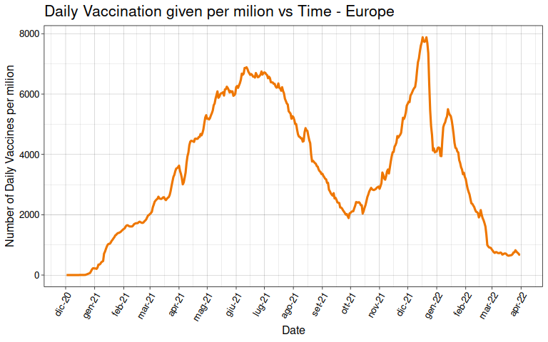

```r
#1 selecting all the European countries in the tibble, plot the number
#of daily vaccinations per million as a function of date
european_vac_df <- vaccinations_data[vaccinations_data$iso_code == "OWID_EUR" ,]

total_vaccines_per_day <- aggregate(european_vac_df$daily_vaccinations_per_million, list(european_vac_df$date), sum)

plot <- ggplot()
plot <- plot + theme_linedraw() + ggtitle('Daily Vaccination given per milion vs Time - Europe')
plot <- plot + labs(x="Date", y="Number of Daily Vaccines per milion")
plot <- plot + theme(plot.title = element_text(size=16),
              axis.text.x = element_text(size=10, angle = 60, hjust = 1),
              axis.text.y = element_text(size=10),
              axis.title.x = element_text(size=12),
              axis.title.y = element_text(size=12)) + scale_x_date(date_breaks = "1 months",date_labels="%b-%y")+                   geom_line( aes(x=european_vac_df$date , y=european_vac_df$daily_vaccinations_per_million), lwd = 1.1 , color='darkorange2')
plot
```

```r
NA
NA
```

2 study the data structure and produce few relevant plots of your taste

```r
colnames(vaccinations_data) #exploring
```

```
 [1] "location"                            "iso_code"
 [3] "date"                                "total_vaccinations"
 [5] "people_vaccinated"                   "people_fully_vaccinated"
 [7] "total_boosters"                      "daily_vaccinations_raw"
 [9] "daily_vaccinations"                  "total_vaccinations_per_hundred"
[11] "people_vaccinated_per_hundred"       "people_fully_vaccinated_per_hundred"
[13] "total_boosters_per_hundred"          "daily_vaccinations_per_million"
[15] "daily_people_vaccinated"             "daily_people_vaccinated_per_hundred"
```

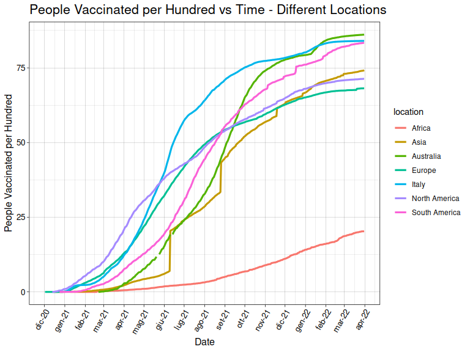

```r
entities <- c("Europe", "Asia", "Africa", "North America", "South America", "Australia", "Italy")
vacc_df_locations <- vaccinations_data[vaccinations_data$location %in% entities, ]

library(ggplot2)


plot <- ggplot(data=vacc_df_locations)
plot <- plot + theme_linedraw() + ggtitle('People Vaccinated per Hundred vs Time - Different Locations')
plot <- plot + labs(x="Date", y="People Vaccinated per Hundred")
plot <- plot + theme(plot.title = element_text(size=16),
              axis.text.x = element_text(size=10, angle = 60, hjust = 1),
              axis.text.y = element_text(size=10),
              axis.title.x = element_text(size=12),
              axis.title.y = element_text(size=12)) + scale_x_date(date_breaks = "1 months",date_labels="%b-%y")+                   geom_line( aes(x=date , y=people_vaccinated_per_hundred , color =location), lwd = 1.1)
plot
```